# Kidney Droplet Notebook

Enter the directory of the maca folder on your drive and the name of the tissue you want to analyze.

```
[1] "Scaling data matrix"
```

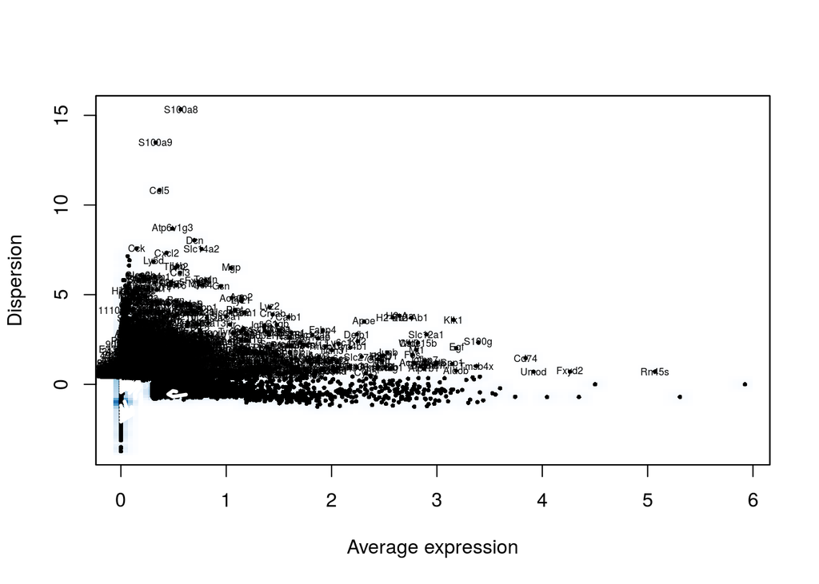

```r
tissue_of_interest = 'Kidney'
library(here)
source(here("00_data_ingest", "02_tissue_analysis_rmd", "boilerplate.R"))
tiss = load_tissue_droplet(tissue_of_interest)
```

Visualize top genes in principal components

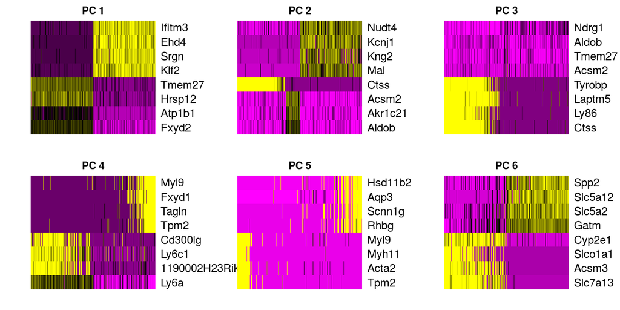

Later on (in FindClusters and TSNE) you will pick a number of principal components to use. This has the effect of keeping the major directions of variation in the data and, ideally, supressing noise. There is no correct answer to the number to use, but a decent rule of thumb is to go until the plot plateaus.

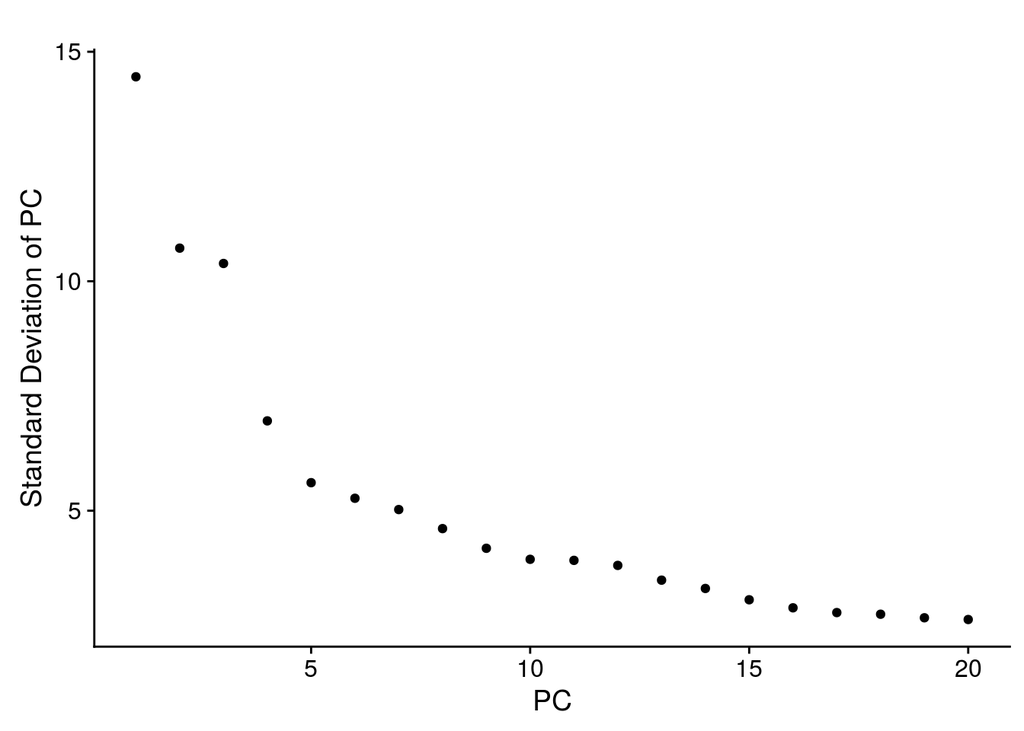

```r
PCElbowPlot(object = tiss)
```

Choose the number of principal components to use.

```r
# Set number of principal components.
n.pcs = 10
```

The clustering is performed based on a nearest neighbors graph. Cells that have similar expression will be joined together. The Louvain algorithm looks for groups of cells with high modularity–more connections within the group than between groups. The resolution parameter determines the scale…higher resolution will give more clusters, lower resolution will give fewer.

For the top-level clustering, aim to under-cluster instead of over-cluster. It will be easy to subset groups and further analyze them below.

```r
# Set resolution
res.used <- 0.5

tiss <- FindClusters(object = tiss, reduction.type = "pca", dims.use = 1:n.pcs,
    resolution = res.used, print.output = 0, save.SNN = TRUE)
```

To visualize

```r
# If cells are too spread out, you can raise the perplexity. If you have few cells, try a lower perplexity (but never less than 10).
tiss <- RunTSNE(object = tiss, dims.use = 1:n.pcs, seed.use = 10, perplexity=100, dim.embed = 2)
```

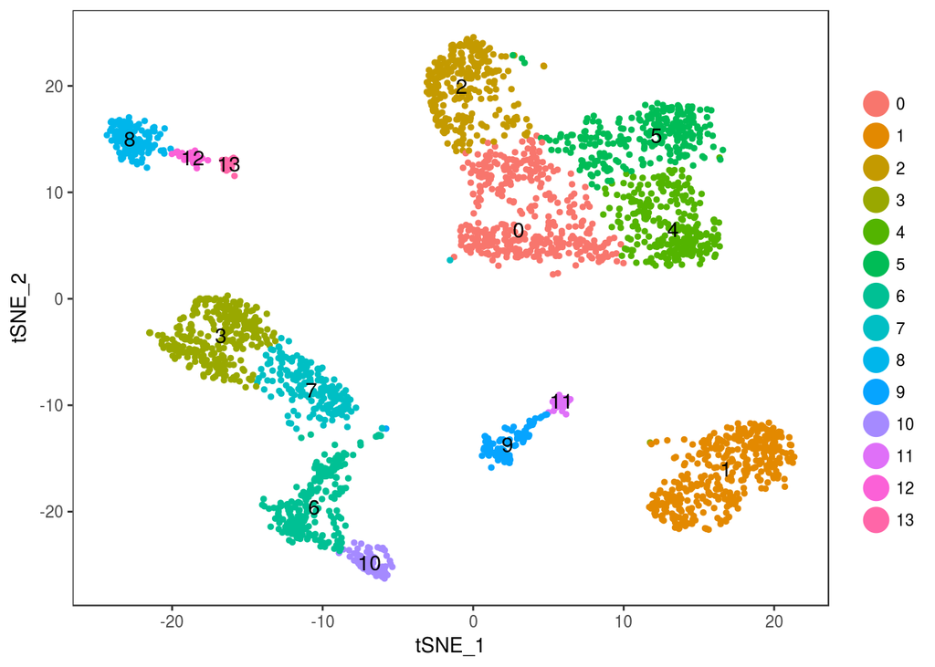

```r
# note that you can set do.label=T to help label individual clusters
TSNEPlot(object = tiss, do.label = T)
```

Compare to previous annotations

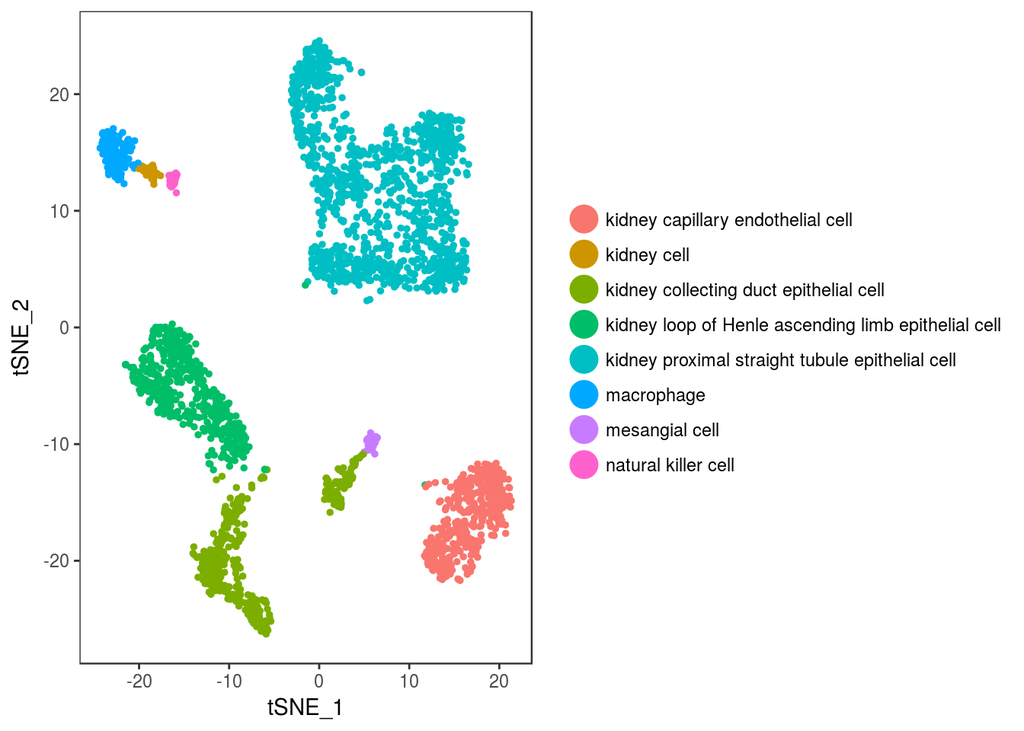

```r
filename = here('00_data_ingest', '03_tissue_annotation_csv',
                     paste0(tissue_of_interest, "_droplet_annotation.csv"))
previous_annotation = read_csv(filename)
tiss@meta.data[, 'previous_annotation'] <- "NA"
tiss@meta.data[as.character(previous_annotation$X1), 'previous_annotation'] <- as.character(previous_annotation$cell_ontology_class)
TSNEPlot(object = tiss, do.return = TRUE, group.by = "previous_annotation")
```

```r
table(tiss@meta.data[, "previous_annotation"])
```

```
                  kidney capillary endothelial cell
                                                392
                                        kidney cell
                                                 45
             kidney collecting duct epithelial cell
                                                443
kidney loop of Henle ascending limb epithelial cell
                                                471
    kidney proximal straight tubule epithelial cell
                                               1198
                                         macrophage
                                                139
                                     mesangial cell
                                                 51
                                natural killer cell
                                                 42
```

```r
table(tiss@meta.data[, "previous_annotation"], tiss@ident)
```

```
                                                        0   1   2   3   4
  kidney capillary endothelial cell                     0 392   0   0   0
  kidney cell                                           0   0   0   0   0
  kidney collecting duct epithelial cell                0   0   0   0   0
  kidney loop of Henle ascending limb epithelial cell   0   0   0 279   0
  kidney proximal straight tubule epithelial cell     395   0 282   0 264
  macrophage                                            0   0   0   0   0
  mesangial cell                                        0   0   0   0   0
  natural killer cell                                   0   0   0   0   0

                                                        5   6   7   8   9
  kidney capillary endothelial cell                     0   0   0   0   0
  kidney cell                                           0   0   0   0   0
  kidney collecting duct epithelial cell                0 244   0   0 117
  kidney loop of Henle ascending limb epithelial cell   0   0 192   0   0
  kidney proximal straight tubule epithelial cell     257   0   0   0   0
  macrophage                                            0   0   0 139   0
  mesangial cell                                        0   0   0   0   0
  natural killer cell                                   0   0   0   0   0

                                                       10  11  12  13
  kidney capillary endothelial cell                     0   0   0   0
  kidney cell                                           0   0  45   0
  kidney collecting duct epithelial cell               82   0   0   0
  kidney loop of Henle ascending limb epithelial cell   0   0   0   0
  kidney proximal straight tubule epithelial cell       0   0   0   0
  macrophage                                            0   0   0   0
  mesangial cell                                        0  51   0   0
  natural killer cell                                   0   0   0  42
```

Check expression of genes of interset. Found inconsistensies in gene names. Mme (Cd10), Ly6g6c, Ly6g6e, and Iga2b though present in plate data was not found here and gave an error.

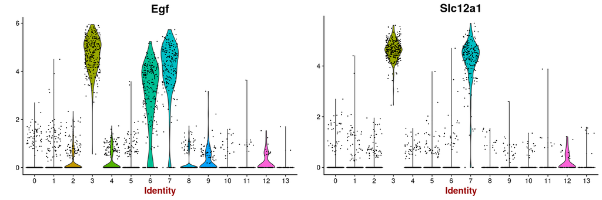

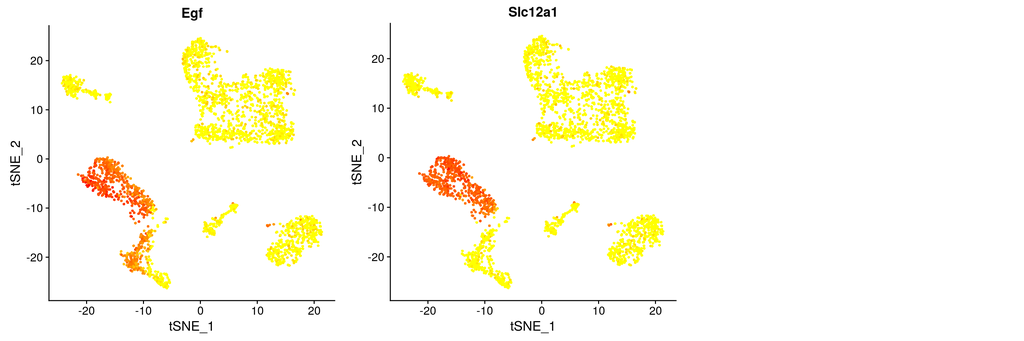

Dotplots let you see the intensity of exppression and the fraction of cells expressing for each of your genes of interest.

[figure not shown]

How big are the clusters?

```r
table(tiss@ident)
```

```
  0   1   2   3   4   5   6   7   8   9  10  11  12  13
395 392 282 279 264 257 244 192 139 117  82  51  45  42
```

## Assigning cell type identity to clusters

At a coarse level, we can use canonical markers to match the unbiased clustering to known cell types:

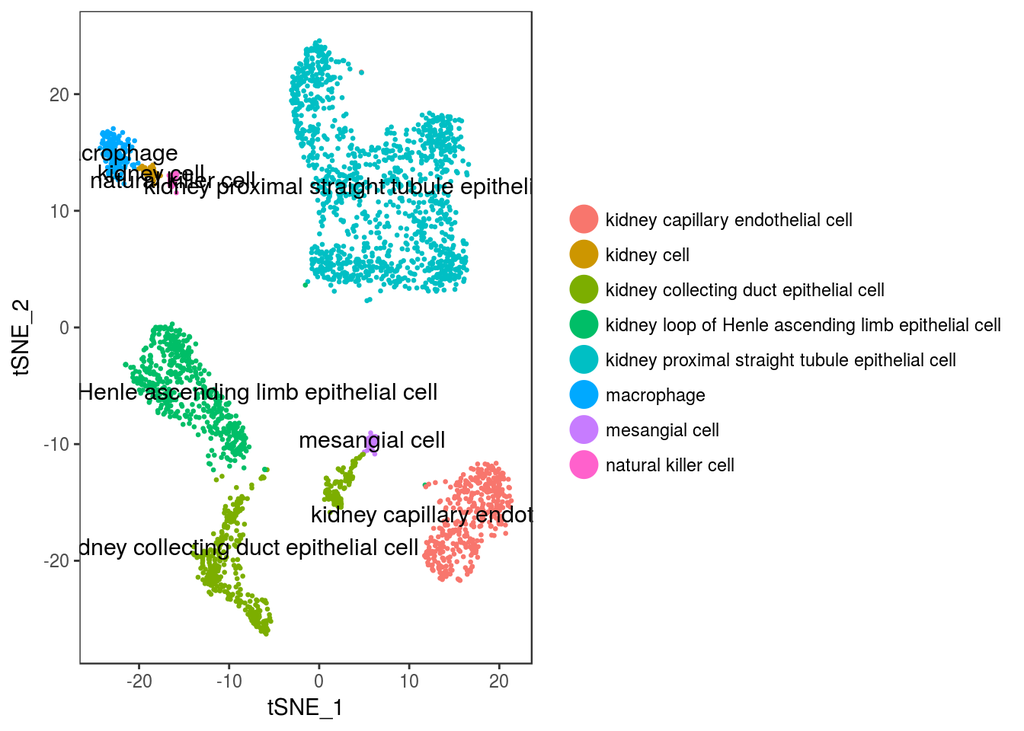

```r
# stash current cluster IDs
tiss <- StashIdent(object = tiss, save.name = "cluster.ids")

# enumerate current cluster IDs and the labels for them
cluster.ids <- c(0, 1, 2, 3, 4, 5, 6, 7, 8, 9, 10, 11, 12, 13)
cell_ontology_class <-
  c(
    "kidney proximal straight tubule epithelial cell",
    "kidney capillary endothelial cell",
    "kidney proximal straight tubule epithelial cell",
    "kidney loop of Henle ascending limb epithelial cell",
    "kidney proximal straight tubule epithelial cell",
    "kidney proximal straight tubule epithelial cell",
    "kidney collecting duct epithelial cell",
    "kidney loop of Henle ascending limb epithelial cell",
    "macrophage",
    "kidney collecting duct epithelial cell",
    "kidney collecting duct epithelial cell",
    "mesangial cell",
    "kidney cell",
    "natural killer cell"
  )

free_annotation <- rep(NA, max(as.numeric(tiss@ident)))


tiss = stash_annotations(tiss, cluster.ids, free_annotation, cell_ontology_class)


TSNEPlot(object = tiss, do.label = TRUE, pt.size = 0.5, group.by='cell_ontology_class')
```

## Checking for batch effects

Color by metadata, like plate barcode, to check for batch effects.

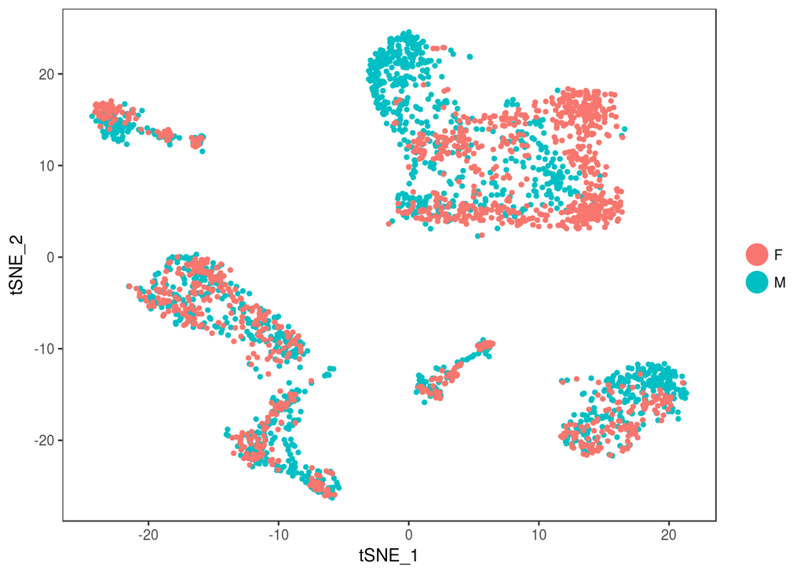

```r
TSNEPlot(object = tiss, do.return = TRUE, group.by = "mouse.sex")
```

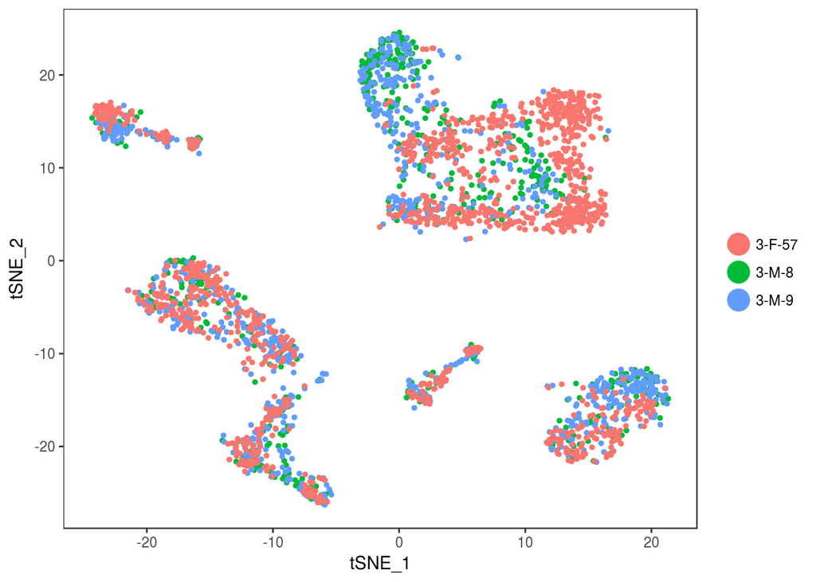

```r
TSNEPlot(object = tiss, do.return = TRUE, group.by = "mouse.id")
```

Print a table showing the count of cells in each identity category from each plate.

```r
table(as.character(tiss@ident), as.character(tiss@meta.data$channel))
```

```
     10X_P4_5 10X_P4_6 10X_P7_5
  0        70      100      225
  1        86      174      132
  10       26       28       28
  11        9       15       27
  12        8       23       14
  13       10       13       19
  2       135      135       12
  3        56       82      141
  4        46       30      188
  5        22       20      215
  6        55      102       87
  7        26       88       78
  8        32       52       55
  9        29       45       43
```

# Save the Robject for later

When you save the annotated tissue, please give it a name.

```r
filename = here('00_data_ingest', '04_tissue_robj_generated',
          paste0("droplet_", tissue_of_interest, "_seurat_tiss.Robj"))
print(filename)
```

```
[1] "/home/rstudio/tabula-muris/00_data_ingest/04_tissue_robj_generated/droplet_Kidney_seurat_tiss.Robj"
```

```r
save(tiss, file=filename)
```

```r
# To reload a saved object
# filename = here('00_data_ingest', '04_tissue_robj_generated',
#                      paste0("droplet_", tissue_of_interest, "_seurat_tiss.Robj"))
# load(file=filename)
```

# Export the final metadata

```r
save_annotation_csv(tiss, tissue_of_interest, "droplet")
```